# Semantic segmentation for Usage and Coverage mapping with Pytorch and TorchGeo

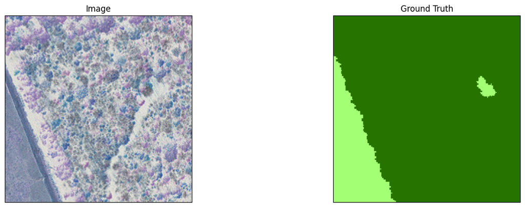

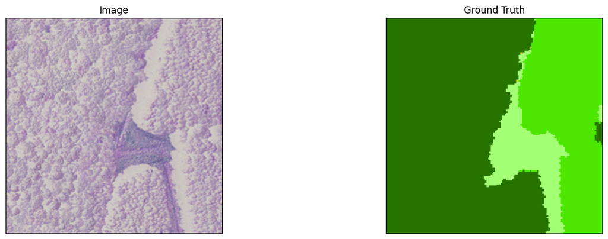

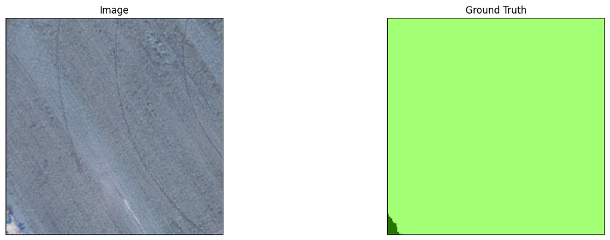

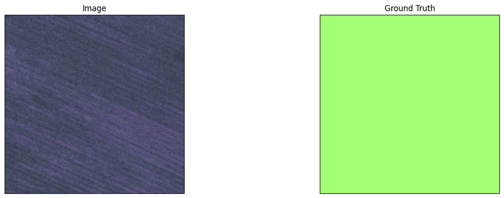

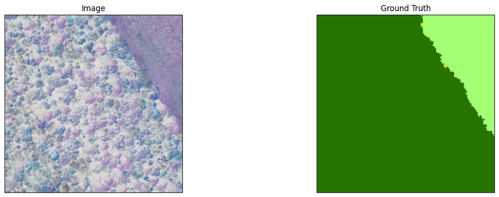

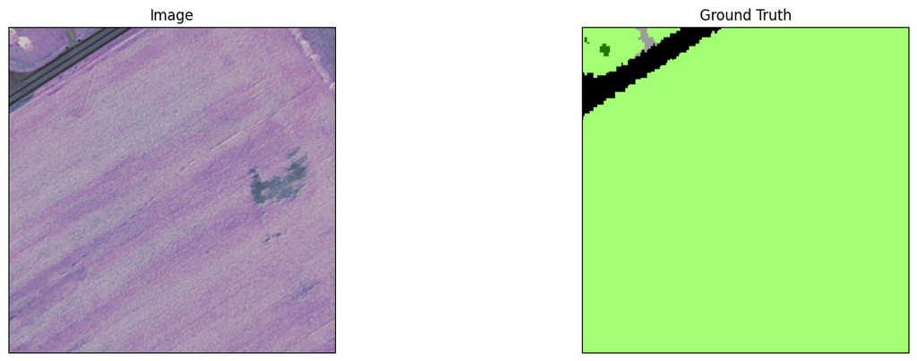

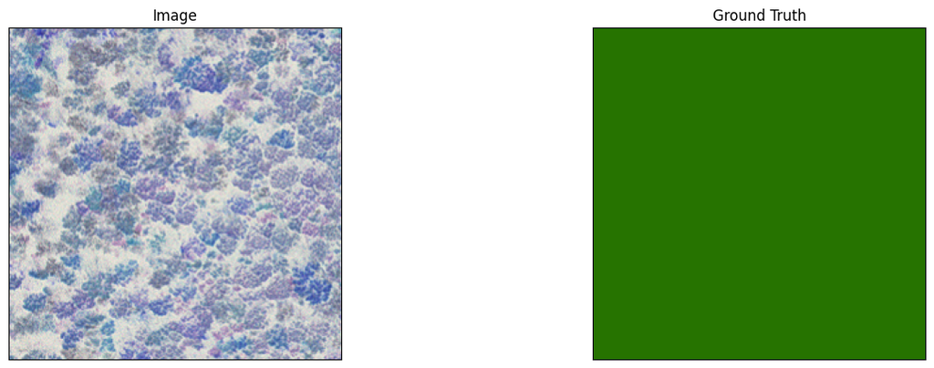

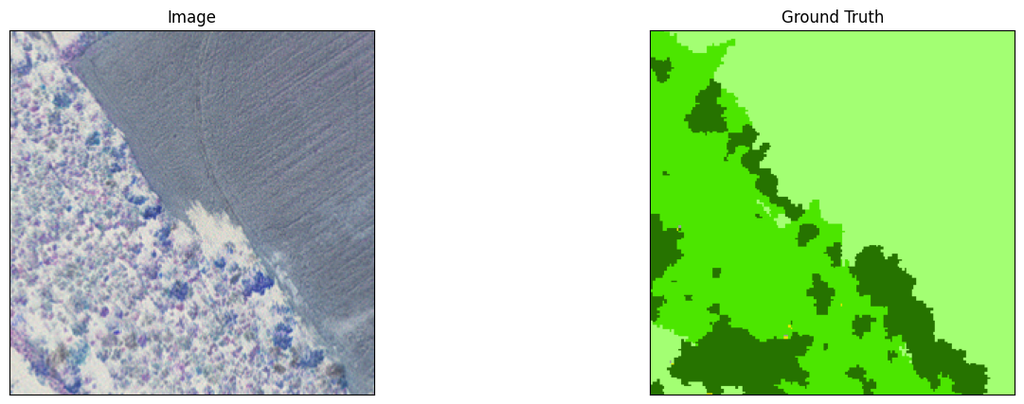

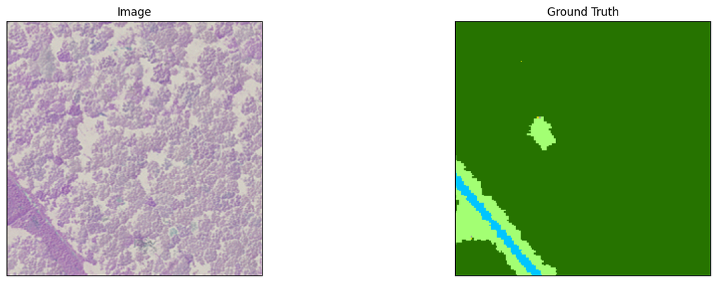

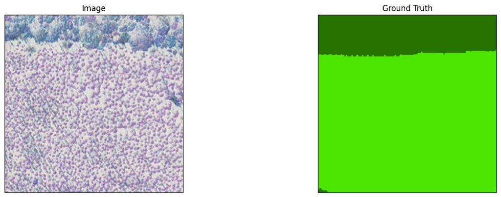

```python
import torchvision.transforms as transforms
reverse_transform = transforms.Compose([
            transforms.ToPILImage(),
            transforms.Resize(size=IMG_SIZE),
        ])

# helper function for data visualization
def visualize(**images):
    """PLot images in one row."""
    n = len(images)
    plt.figure(figsize=(16, 5))
    for i, (name, image) in enumerate(images.items()):
        plt.subplot(1, n, i + 1)
        plt.xticks([])
        plt.yticks([])
        plt.title(' '.join(name.split('_')).title())
        plt.imshow(image)
    plt.show()

n = 0
for sample in dataloader:
    if n == 10:
        break
    image, gt_mask = sample['image'], sample['mask']

    gt_mask = colour_code_segmentation(gt_mask, cmap)

    visualize(
        image=reverse_transform(image.squeeze()[:3]),
        ground_truth = gt_mask.squeeze(),
    )
    n += 1
```

With everything ready, let's run the model training and validation:

```python
start = timeit.default_timer() # Measuring the time

checkpoint_file = os.path.join(TEST_DIR, 'torchgeo_trained.ckpt')

if os.path.isfile(checkpoint_file):
    print('Resuming training from previous checkpoint...')
    trainer.fit(
        model=task,
        datamodule=datamodule,
        ckpt_path=checkpoint_file
    )
else:
    print('Starting training from scratch...')
    trainer.fit(
        model=task,
        datamodule = datamodule,
    )

print("The time taken to train was: ", timeit.default_timer() - start)
```

```
Starting training from scratch...
```

```
Sanity Checking: 0it [00:00, ?it/s]
```

```
Training: 0it [00:00, ?it/s]
```

[output not shown]

[output not shown]

[output not shown]

[output not shown]

[output not shown]

[output not shown]

[output not shown]

[output not shown]

[output not shown]

[output not shown]

[output not shown]

[output not shown]

[output not shown]

[output not shown]

[output not shown]

```
INFO: `Trainer.fit` stopped: `max_epochs=15` reached.
INFO:lightning.pytorch.utilities.rank_zero:`Trainer.fit` stopped: `max_epochs=15` reached.
```

```
The time taken to train was:  338.4465540860001
```

Once trained, let's apply it to the test data:

```python
trainer.test(
    model=task,
    datamodule=datamodule
)
```

```
INFO: LOCAL_RANK: 0 - CUDA_VISIBLE_DEVICES: [0]
INFO:lightning.pytorch.accelerators.cuda:LOCAL_RANK: 0 - CUDA_VISIBLE_DEVICES: [0]
```

```
Testing: 0it [00:00, ?it/s]
```

```
┏━━━━━━━━━━━━━━━━━━━━━━━━━━━━━┳━━━━━━━━━━━━━━━━━━━━━━━━━━━━━┓
┃         Test metric         ┃        DataLoader 0         ┃
┡━━━━━━━━━━━━━━━━━━━━━━━━━━━━━╇━━━━━━━━━━━━━━━━━━━━━━━━━━━━━┩
│   test_MulticlassAccuracy   │     0.8992854952812195      │
│ test_MulticlassJaccardIndex │     0.8170016407966614      │
│          test_loss          │    8.787868864601478e-06    │
└─────────────────────────────┴─────────────────────────────┘
```

```
[{'test_loss': 8.787868864601478e-06,
  'test_MulticlassAccuracy': 0.8992854952812195,
  'test_MulticlassJaccardIndex': 0.8170016407966614}]
```

Once trained and validated, we will use one of the NAIP orthomosaics to make the full prediction. First, we load the orthomosaic, divide it into patches, and perform the prediction for each patch. Then, we apply a Merge to the predicted patches and generate the georeferenced result:

```python
def create_in_memory_geochip(predicted_chip, geotransform, crs):
    """
    Apply georeferencing to the predicted chip.

    Parameters:
        predicted_chip (numpy array): The predicted segmentation chip (e.g., binary mask).
        geotransform (tuple): A tuple containing the geotransformation information of the chip (x-coordinate of the top left corner, x and y pixel size, rotation, y-coordinate of the top left corner, and rotation).
        crs (str): Spatial Reference System (e.g., EPSG code) of the chip.

    Return:
        A rasterio dataset that is georreferenced.
    """
    memfile = MemoryFile()
    dataset = memfile.open(
        driver='GTiff',
        height=predicted_chip.shape[0],
        width=predicted_chip.shape[1],
        count=predicted_chip.shape[2],  # Number of bands
        dtype=np.uint8,
        crs=crs,
        transform=geotransform,
        photometric='RGBA',
    )

    rolled_array = np.rollaxis(predicted_chip, axis=2) # putting the bands first
    dataset.write(rolled_array)
    return dataset
```

```python
def georreferenced_chip_generator(dataloader, model, crs, pixel_size, colors):
    """
    Apply georeferencing to the predicted chip.

    Parameters:
        dataloader (torch.utils.data.Dataloader): Dataloader with the data to be predicted.
        model (an https://github.com/qubvel/segmentation_models.pytorch model): model used for inference.
        crs (str): Spatial Reference System (e.g., EPSG code) of the chip.
        pixel_size (float): Pixel dimensoion in map units.

    Yields:
        A georeferenced numpy array of the predicted output.
    """
    georref_chips_list = []
    for i, sample in enumerate(dataloader):
        '''
        if i == 10:
            break
        '''

        image, gt_mask, bbox = sample['image'], sample['mask'], sample['bbox'][0]

        image = image/255. # as I'm not using a GeoDatamodule, I need to divide de images by 255 manually

        prediction = model.predict(image)
        prediction = torch.softmax(prediction, dim=1)
        prediction = torch.argmax(prediction, dim = 1)

        # reapplying the original colors in the reversed one hot images
        #gt_mask = colour_code_segmentation(gt_mask, colors)
        prediction = colour_code_segmentation(prediction, colors)

        geotransform = from_origin(bbox.minx, bbox.maxy, pixel_size, pixel_size)
        #yield create_in_memory_geochip(prediction.squeeze(), geotransform, crs)
        georref_chips_list.append(create_in_memory_geochip(prediction.squeeze(), geotransform, crs))
    return georref_chips_list
```

```python
def merge_georeferenced_chips(chips_generator, output_path):
    """
    Merge a list of georeferenced chips into a single GeoTIFF file.

    Parameters:
        chips_generator (generator): A generator of Rasterio datasets representing the georeferenced chips.
        output_path (str): The path where the merged GeoTIFF file will be saved.

    Returns:
        None
    """
    #chips_list = list(chips_generator)
    chips_list = chips_generator
    # Merge the chips using Rasterio's merge function
    merged, merged_transform = merge(chips_list)

    # Calculate the number of rows and columns for the merged output
    rows, cols = merged.shape[1], merged.shape[2]

    # Update the metadata of the merged dataset
    merged_metadata = chips_list[0].meta
    merged_metadata.update({
        'height': rows,
        'width': cols,
        'transform': merged_transform
    })

    # Write the merged array to a new GeoTIFF file
    with rasterio.open(output_path, 'w', **merged_metadata) as dst:
        dst.write(merged)

    for chip in chips_list:
        chip.close()
```

```python
test_dataset = datamodule.test_dataset
test_sampler = GridGeoSampler(test_dataset, 2048, 2048)
test_dataloader = DataLoader(test_dataset, sampler=test_sampler, collate_fn=stack_samples)

pixel_size = test_dataset.res
crs = test_dataset.crs.to_epsg()

start = timeit.default_timer() # Measuring the time
chips_generator = georreferenced_chip_generator(test_dataloader, task.model, crs, pixel_size, cmap)
print("The time taken to predict was: ", timeit.default_timer() - start)

start = timeit.default_timer() # Measuring the time
file_name = os.path.join(OUTPUT_DIR, 'merged_prediction.tif')
merge_georeferenced_chips(chips_generator, file_name)
print("The time taken to generate a georrefenced image and save it was: ", timeit.default_timer() - start)
```

[output not shown]

[output cut: 44 more lines]

```
The time taken to predict was:  418.4003023790001
The time taken to generate a georrefenced image and save it was:  4.671972782000012
```

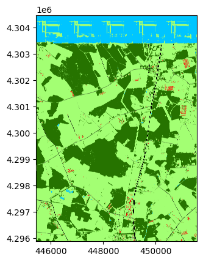

```python
output_filepath = os.path.join(OUTPUT_DIR, 'merged_prediction.tif')
src = rasterio.open(output_filepath)
show(src.read(), transform=src.transform)
```

Reference:

https://www.kaggle.com/code/luizclaudioandrade/torchgeo-101

https://torchgeo.readthedocs.io/en/stable/tutorials/getting_started.html

https://pytorch.org/blog/geospatial-deep-learning-with-torchgeo/